# ntpParking

蔡欽堯 / 李思穎

2016年10月22日

```r
cat("
<style>
div.des {
  background-color : rgb(23, 21, 27);
  color : white;
  margin : 20px 0 20px 0;
  padding : 20px;
  font-family : Arial, Helvetica, sans-serif;
  font-size : 16px;
}

div.res {
  background-color : blue;
  color : white;
  margin : 20px 0 20px 0;
  padding : 20px;
  font-family : Arial, Helvetica, sans-serif;
  font-size : 16px;
}
</style>
")
```

加載library  
library(“dplyr”)  
library(“jsonlite”)  
library(“leaflet”)  
library(plotrix)

```r
  library("dplyr")
```

```r
  library("jsonlite")
  library("leaflet")
  library("plotrix")
```

匯入資料  
資料格式 : JSON / CSV  
資料內容 : 新北市路外公共停車場資訊 / 新北市公有路外停車場即時賸餘車位數  
收集時間 : 10 / 17 ~ 10 / 19 日08:00、12:00、16:00、20:00、23:00

資料處理方式  
(1) 將15個路外停車場即時賸餘車位數CSV檔案匯入，另外透過url自網路取得新北市路外公共停車場資訊的Json data  
(2) 針對資料中有重複性的停車場ID資訊進行過濾  
(3) 再依據有提供即時車位資訊的停車場進行過濾  
(4) 過濾掉停車場資訊中車位數小於即時剩餘車位的資訊( 不合理的資訊 )  
(5) 將TWD97座標系統資訊轉成WGS84座標系統資訊  
(6) 將16筆資料整併到一個data frame，並將WGS84座標系統資訊加入到data frame中

```r
# setwd("d:/Dropbox/R/avaPark")

dtp <- c("p1708", "p1712", "p1716", "p1720", "p1723",
         "p1808", "p1812", "p1816", "p1820", "p1823",
         "p1908", "p1912", "p1916", "p1920", "p1923")
temp = list.files(pattern = "*.csv")

for(i in 1:length(temp))
  assign(dtp[i], read.csv(temp[i],
                          fileEncoding = "BIG-5",
                          stringsAsFactors = F))

# 新北市路外公共停車場資訊
url <- 'http://data.ntpc.gov.tw/api/v1/rest/datastore/382000000A-000225-002'
park <- fromJSON(url)
park <- as.data.frame(park[[2]]$records)

# 重新進行排序
park <- park[with(park, order(ID)), ]

# 過濾掉重複的ID車場
park <- park[!duplicated(park[, 'ID']), ]

park <- park[which(park$AREA == "板橋區"), ]
park$ID <- as.integer(park$ID)
park$TOTALCAR <- as.integer(ifelse(is.na(park$TOTALCAR), 0, park$TOTALCAR))

# 過濾掉重複的ID車場以及未提供即時剩餘車位的資訊
p1708 <- p1708[!duplicated(p1708[, 'ID']), ]
p1708 <- p1708[which(p1708$X1708 != -9),]

p1712 <- p1712[!duplicated(p1712[, 'ID']), ]
p1712 <- p1712[which(p1712$X1712 != -9),]

p1716 <- p1716[!duplicated(p1716[, 'ID']), ]
p1716 <- p1716[which(p1716$X1716 != -9),]

p1720 <- p1720[!duplicated(p1720[, 'ID']), ]
p1720 <- p1720[which(p1720$X1720 != -9),]

p1723 <- p1723[!duplicated(p1723[, 'ID']), ]
p1723 <- p1723[which(p1723$X1723 != -9),]

p1808 <- p1808[!duplicated(p1808[, 'ID']), ]
p1808 <- p1808[which(p1808$X1808 != -9),]

p1812 <- p1812[!duplicated(p1812[, 'ID']), ]
p1812 <- p1812[which(p1812$X1812 != -9),]

p1816 <- p1816[!duplicated(p1816[, 'ID']), ]
p1816 <- p1816[which(p1816$X1816 != -9),]

p1820 <- p1820[!duplicated(p1820[, 'ID']), ]
p1820 <- p1820[which(p1820$X1820 != -9),]

p1823 <- p1823[!duplicated(p1823[, 'ID']), ]
p1823 <- p1823[which(p1823$X1823 != -9),]

p1908 <- p1908[!duplicated(p1908[, 'ID']), ]
p1908 <- p1908[which(p1908$X1908 != -9),]

p1912 <- p1912[!duplicated(p1912[, 'ID']), ]
p1912 <- p1912[which(p1912$X1912 != -9),]

p1916 <- p1916[!duplicated(p1916[, 'ID']), ]
p1916 <- p1916[which(p1916$X1916 != -9),]

p1920 <- p1920[!duplicated(p1920[, 'ID']), ]
p1920 <- p1920[which(p1920$X1920 != -9),]

p1923 <- p1923[!duplicated(p1923[, 'ID']), ]
p1923 <- p1923[which(p1923$X1923 != -9),]

source("TWD97TM2toWGS84.R")
WGS84 <- TWD97TM2toWGS84(park$TW97X, park$TW97Y)

ptable <-
  park %>%
  mutate(WGS84X = WGS84$lat) %>%
  mutate(WGS84Y = WGS84$lon) %>%
  merge(p1708, by = "ID", all = FALSE) %>%
  merge(p1712, by = "ID", all = FALSE) %>%
  merge(p1716, by = "ID", all = FALSE) %>%
  merge(p1720, by = "ID", all = FALSE) %>%
  merge(p1723, by = "ID", all = FALSE) %>%
  merge(p1808, by = "ID", all = FALSE) %>%
  merge(p1812, by = "ID", all = FALSE) %>%
  merge(p1816, by = "ID", all = FALSE) %>%
  merge(p1820, by = "ID", all = FALSE) %>%
  merge(p1823, by = "ID", all = FALSE) %>%
  merge(p1908, by = "ID", all = FALSE) %>%
  merge(p1912, by = "ID", all = FALSE) %>%
  merge(p1916, by = "ID", all = FALSE) %>%
  merge(p1920, by = "ID", all = FALSE) %>%
  merge(p1923, by = "ID", all = FALSE)

# 過濾掉停車場資訊中車位數小於即時剩餘車位的資訊( 不合理的資訊 )
ptable <- ptable[which(ptable$TOTALCAR > ptable$X1708 &
                         ptable$TOTALCAR > ptable$X1712 &
                         ptable$TOTALCAR > ptable$X1716 &
                         ptable$TOTALCAR > ptable$X1720 &
                         ptable$TOTALCAR > ptable$X1723 &
                         ptable$TOTALCAR > ptable$X1808 &
                         ptable$TOTALCAR > ptable$X1812 &
                         ptable$TOTALCAR > ptable$X1816 &
                         ptable$TOTALCAR > ptable$X1820 &
                         ptable$TOTALCAR > ptable$X1823 &
                         ptable$TOTALCAR > ptable$X1908 &
                         ptable$TOTALCAR > ptable$X1912 &
                         ptable$TOTALCAR > ptable$X1916 &
                         ptable$TOTALCAR > ptable$X1920 &
                         ptable$TOTALCAR > ptable$X1923), ]

head(ptable)
```

```
##      ID   AREA                     NAME TYPE                   SUMMARY
## 1 10001 板橋區           莊敬立體停車場    1 立體式-塔臺都市計畫停車場
## 2 10004 板橋區           民生花市停車場    1      平面式都市計畫停車場
## 3 10009 板橋區           民權立體停車場    1      立體式都市計畫停車場
## 4 10010 板橋區               新埔停車場    1 立體式-塔臺都市計畫停車場
## 5 10011 板橋區 板橋區重慶公園地下停車場    1    立體式多目標附建停車場
## 6 10013 板橋區       市民廣場地下停車場    1      立體式都市計畫停車場
##                             ADDRESS        TEL
## 1             新北市板橋區莊敬路2號  2258-1026
## 2           民生路2段200及207號對面   22259110
## 3                  板橋區民權路89號  8969-8326
## 4                 板橋區英士路199號 ,2258-1641
## 5     新北市板橋區重慶路265號B1、B2  2955-4868
## 6 新北市板橋區縣民大道二段22號B1-B3   29643298
##                                                                                  PAYEX
```

[output cut: 27 more lines]

```r
tail(ptable)
```

```
##       ID   AREA                                 NAME TYPE
## 31 10110 板橋區   新北市板橋區板橋高級中學地下停車場    1
## 32 10131 板橋區 新北市板橋區新北市立圖書館地下停車場    1
## 33 10139 板橋區               江翠水岸停二收費停車場    1
## 34 10140 板橋區               江翠水岸停一收費停車場    1
## 35 10146 板橋區         江翠國中游泳池共構地下停車場    1
## 36 10149 板橋區                           大漢停車場    1
##                   SUMMARY
## 31 立體式多目標附建停車場
## 32 立體式建築附設停車空間
## 33   平面式都市計畫停車場
## 34   平面式都市計畫停車場
## 35 立體式多目標附建停車場
## 36 立體式多目標附建停車場
##                                                ADDRESS      TEL
```

[output cut: 34 more lines]

```r
for(i in 1 : nrow(ptable)){
  ptable$used_x1708[i] = ptable$TOTALCAR[i] - ptable$X1708[i]
  ptable$used_x1712[i] = ptable$TOTALCAR[i] - ptable$X1712[i]
  ptable$used_x1716[i] = ptable$TOTALCAR[i] - ptable$X1716[i]
  ptable$used_x1720[i] = ptable$TOTALCAR[i] - ptable$X1720[i]
  ptable$used_x1723[i] = ptable$TOTALCAR[i] - ptable$X1723[i]
  ptable$used_x1808[i] = ptable$TOTALCAR[i] - ptable$X1808[i]
  ptable$used_x1812[i] = ptable$TOTALCAR[i] - ptable$X1812[i]
  ptable$used_x1816[i] = ptable$TOTALCAR[i] - ptable$X1816[i]
  ptable$used_x1820[i] = ptable$TOTALCAR[i] - ptable$X1820[i]
  ptable$used_x1823[i] = ptable$TOTALCAR[i] - ptable$X1823[i]
  ptable$used_x1908[i] = ptable$TOTALCAR[i] - ptable$X1908[i]
  ptable$used_x1912[i] = ptable$TOTALCAR[i] - ptable$X1912[i]
  ptable$used_x1916[i] = ptable$TOTALCAR[i] - ptable$X1916[i]
  ptable$used_x1920[i] = ptable$TOTALCAR[i] - ptable$X1920[i]
  ptable$used_x1923[i] = ptable$TOTALCAR[i] - ptable$X1923[i]
  ptable$avamean[i] = mean(c(ptable$X1708[i], ptable$X1712[i],
                             ptable$X1716[i], ptable$X1720[i],
                             ptable$X1723[i], ptable$X1808[i],
                             ptable$X1812[i], ptable$X1816[i],
                             ptable$X1820[i], ptable$X1823[i],
                             ptable$X1908[i], ptable$X1912[i],
                             ptable$X1916[i], ptable$X1920[i],
                             ptable$X1923[i]))

  ptable$UsedRate_x1708[i] = ptable$used_x1708[i] / ptable$TOTALCAR[i]
  ptable$UsedRate_x1712[i] = ptable$used_x1712[i] / ptable$TOTALCAR[i]
  ptable$UsedRate_x1716[i] = ptable$used_x1716[i] / ptable$TOTALCAR[i]
  ptable$UsedRate_x1720[i] = ptable$used_x1720[i] / ptable$TOTALCAR[i]
  ptable$UsedRate_x1723[i] = ptable$used_x1723[i] / ptable$TOTALCAR[i]
  ptable$UsedRate_x1808[i] = ptable$used_x1808[i] / ptable$TOTALCAR[i]
  ptable$UsedRate_x1812[i] = ptable$used_x1812[i] / ptable$TOTALCAR[i]
  ptable$UsedRate_x1816[i] = ptable$used_x1816[i] / ptable$TOTALCAR[i]
  ptable$UsedRate_x1820[i] = ptable$used_x1820[i] / ptable$TOTALCAR[i]
  ptable$UsedRate_x1823[i] = ptable$used_x1823[i] / ptable$TOTALCAR[i]
  ptable$UsedRate_x1908[i] = ptable$used_x1908[i] / ptable$TOTALCAR[i]
  ptable$UsedRate_x1912[i] = ptable$used_x1912[i] / ptable$TOTALCAR[i]
  ptable$UsedRate_x1916[i] = ptable$used_x1916[i] / ptable$TOTALCAR[i]
  ptable$UsedRate_x1920[i] = ptable$used_x1920[i] / ptable$TOTALCAR[i]
  ptable$UsedRate_x1923[i] = ptable$used_x1923[i] / ptable$TOTALCAR[i]
  ptable$UseRatemean[i] = mean(c(ptable$UsedRate_x1708[i], ptable$UsedRate_x1712[i],
                                 ptable$UsedRate_x1716[i], ptable$UsedRate_x1720[i],
                                 ptable$UsedRate_x1723[i], ptable$UsedRate_x1808[i],
                                 ptable$UsedRate_x1812[i], ptable$UsedRate_x1816[i],
                                 ptable$UsedRate_x1820[i], ptable$UsedRate_x1823[i],
                                 ptable$UsedRate_x1908[i], ptable$UsedRate_x1912[i],
                                 ptable$UsedRate_x1916[i], ptable$UsedRate_x1920[i],
                                 ptable$UsedRate_x1923[i]))
}
```

板橋區停車場 10 / 17 ~ 10 / 19 平均使用率分布地圖

```r
pal <- colorBin(palette = c("green", "pink", "blue", "orange", "red"),
                bin = c(0, 0.2, 0.4, 0.6, 0.8, 1.0),
                pretty = TRUE,
                na.color = "black",
                alpha = F)
```

板橋區停車場 10 / 17 ~ 10 / 19 平均使用率分布  
20% 以下 : 綠色  
20% ~ 40% : 粉紅色  
40% ~ 60% : 藍色  
60% ~ 80% : 橘色  
80% 以上 : 紅色

```r
getrRadius <- function(x){
  ifelse(ptable$avamean < 20, 15,
         ifelse(ptable$avamean < 40, 20,
                ifelse(ptable$avamean < 60, 25,
                       ifelse(ptable$avamean < 80, 30, 35))))
}

map <-
  leaflet() %>%
  addTiles() %>%  # 加上預設的地圖資料
  addCircles(lat = ptable$WGS84X,
                   lng = ptable$WGS84Y,
                   radius = getrRadius(ptable$avamean),
                   popup = paste("名稱:", ptable$NAME, "<br>",
                                 "停車場類型:", ptable$SUMMARY, "<br>",
                                 "車位數量:", ptable$TOTALCAR, "<br>",
                                 "地址:", ptable$ADDRESS, "<br>",
                                 "平均使用率:", ptable$UseRatemean, "<br>",
                                 "平均剩餘空位數:", ptable$avamean),
                   color = pal(ptable$UseRatemean))
map  # 繪製地圖
```

[interactive chart not shown]

```r
rateCnt <- c(usg0to20 = length(which(ptable$UseRatemean <= 0.2)) / length(ptable$UseRatemean),
             usg20to40 = length(which(ptable$UseRatemean <= 0.4 & ptable$UseRatemean > 0.2)) / length(ptable$UseRatemean),
             usg40t060 = length(which(ptable$UseRatemean <= 0.6 & ptable$UseRatemean > 0.4)) / length(ptable$UseRatemean),
             usg60to80 = length(which(ptable$UseRatemean <= 0.8 & ptable$UseRatemean > 0.6)) / length(ptable$UseRatemean),
             usg80to100 = length(which(ptable$UseRatemean > 0.8)) / length(ptable$UseRatemean))

rateCnt
```

```
##   usg0to20  usg20to40  usg40t060  usg60to80 usg80to100
## 0.02857143 0.05714286 0.11428571 0.28571429 0.51428571
```

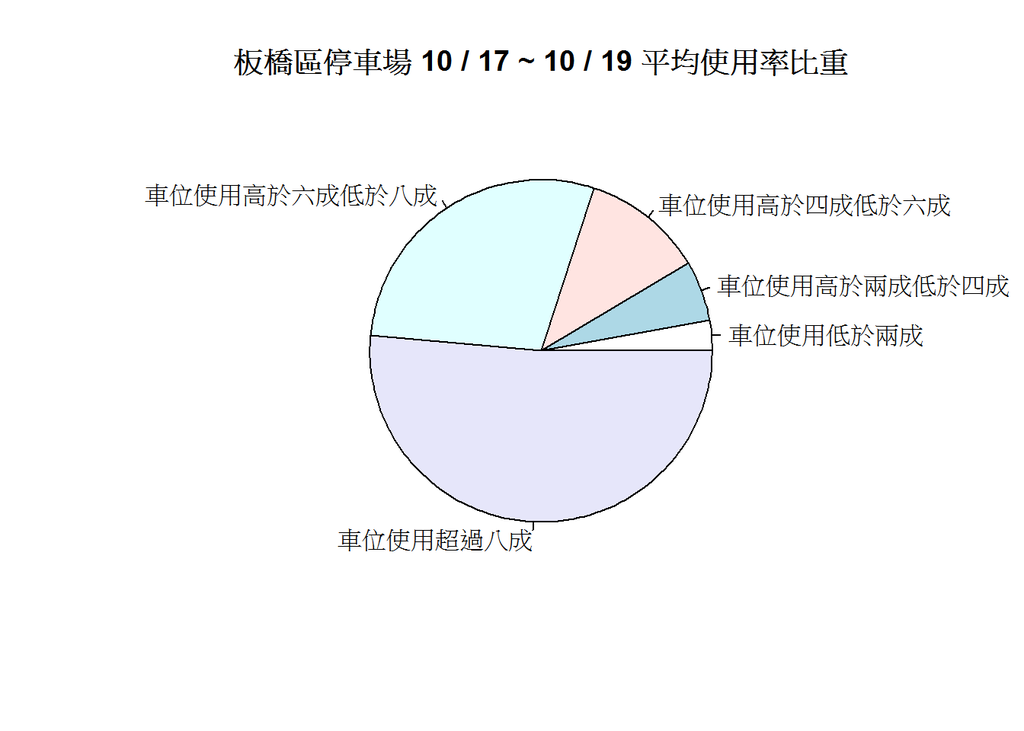

```r
pie(rateCnt,
    # explode = 0.1,
    labels = c("車位使用低於兩成",
               "車位使用高於兩成低於四成",
               "車位使用高於四成低於六成",
               "車位使用高於六成低於八成",
               "車位使用超過八成"),
    main = "板橋區停車場 10 / 17 ~ 10 / 19 平均使用率比重")
```

比較板橋區不同類型停車場的平均使用率

```r
# 比較板橋區不同類型停車場的平均使用率
sumTable3 <-
ptable %>%
  filter(AREA == "板橋區")%>%
  select(
    SUMMARY, UsedRate_x1708, UsedRate_x1712, UsedRate_x1716, UsedRate_x1720, UsedRate_x1723,
    UsedRate_x1808, UsedRate_x1812, UsedRate_x1816, UsedRate_x1820, UsedRate_x1823,
    UsedRate_x1908, UsedRate_x1912, UsedRate_x1916, UsedRate_x1920, UsedRate_x1923
  ) %>%
  group_by(SUMMARY) %>%
  summarise(
    "AVRUR(%)" = round(mean(c(UsedRate_x1708, UsedRate_x1712, UsedRate_x1716,
                     UsedRate_x1720, UsedRate_x1723, UsedRate_x1808,
                     UsedRate_x1812, UsedRate_x1816, UsedRate_x1820,
                     UsedRate_x1823, UsedRate_x1908, UsedRate_x1912,
                     UsedRate_x1916, UsedRate_x1920, UsedRate_x1923)),digits = 3) * 100
  )
```

停車場類型  
type1 : 平面式多目標附建停車場  
type2 : 平面式都市計畫停車場  
type3 : 平面式臨時路外停車場  
type4 : 立體式-塔臺都市計畫停車場  
type5 : 立體式-機械多目標附建停車場  
type6 : 立體式多目標附建停車場  
type7 : 立體式建築附設停車空間  
type8 : 立體式都市計畫停車場

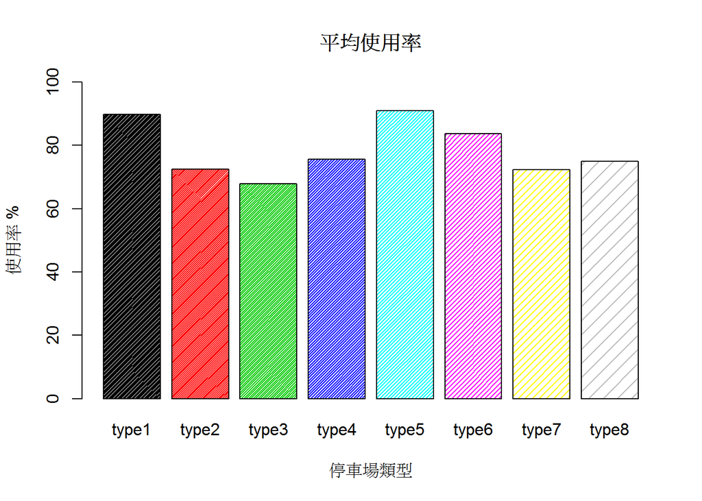

```r
barplot(sumTable3$`AVRUR(%)`,
        main = "平均使用率",
        ylab="使用率 %",
        xlab="停車場類型",
        col = c(1:8),
        ylim = c(0, 100),
        names.arg = c("type1", "type2", "type3", "type4",
                      "type5", "type6", "type7", "type8"),
        density=c(80,70,60,50,40,30,20,10))
```

板橋區不同時間點(0800, 1200, 1600, 2000, 2300)的平均使用率

```r
# 板橋區不同時間點(0800, 1200, 1600, 2000, 2300)的平均使用率
sumTable2 <-
ptable %>%
  filter(AREA == "板橋區")%>%
  select(UsedRate_x1708, UsedRate_x1712, UsedRate_x1716, UsedRate_x1720, UsedRate_x1723,
         UsedRate_x1808, UsedRate_x1812, UsedRate_x1816, UsedRate_x1820, UsedRate_x1823,
         UsedRate_x1908, UsedRate_x1912, UsedRate_x1916, UsedRate_x1920, UsedRate_x1923
  ) %>%
  summarise(
    "0800_AVRUR(%)" = round(mean(c(UsedRate_x1708,UsedRate_x1808,UsedRate_x1908)),
                            digits = 3) * 100,
    "1200_AVRUR(%)" = round(mean(c(UsedRate_x1712,UsedRate_x1812,UsedRate_x1912)),
                            digits = 3) * 100,
    "1600_AVRUR(%)" = round(mean(c(UsedRate_x1716,UsedRate_x1816,UsedRate_x1916)),
                            digits = 3) * 100,
    "2000_AVRUR(%)" = round(mean(c(UsedRate_x1720,UsedRate_x1820,UsedRate_x1920)),
                            digits = 3) * 100,
    "2300_AVRUR(%)" = round(mean(c(UsedRate_x1723,UsedRate_x1823,UsedRate_x1923)),
                            digits = 3) * 100
  )
```

時間 vs 平均使用率

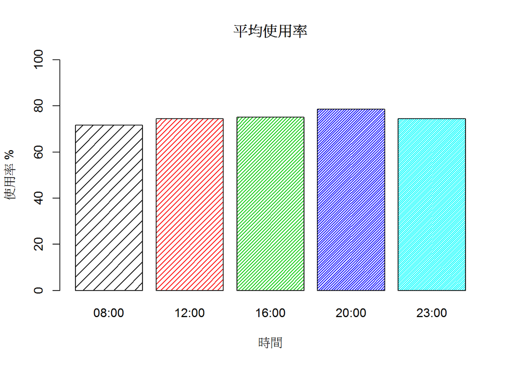

```r
barplot(c(sumTable2[1, 1], sumTable2[1, 2], sumTable2[1, 3], sumTable2[1, 4], sumTable2[1, 5]),
        main = "平均使用率",
        ylab="使用率 %",
        xlab="時間",
        col = c(1:5),
        ylim = c(0, 100),
        names.arg = c("08:00", "12:00", "16:00", "20:00",
                      "23:00"),
        density=c(10,20,30,40,50))
```

停車場類型不同時間點的平均使用率

```r
# 比較板橋區不同類型停車場 & 不同時間點的平均使用率
sumTable <-
ptable %>%
  filter(AREA == "板橋區")%>%
  select(SUMMARY, UsedRate_x1708, UsedRate_x1712, UsedRate_x1716,
         UsedRate_x1720, UsedRate_x1723, UsedRate_x1808, UsedRate_x1812,
         UsedRate_x1816, UsedRate_x1820, UsedRate_x1823, UsedRate_x1908,
         UsedRate_x1912, UsedRate_x1916, UsedRate_x1920, UsedRate_x1923) %>%
  group_by(SUMMARY) %>%
  summarise(
  "AllTime_AVRTU(%)" = round(mean(c(
    UsedRate_x1708, UsedRate_x1712, UsedRate_x1716, UsedRate_x1720, UsedRate_x1723,
    UsedRate_x1808, UsedRate_x1812, UsedRate_x1816, UsedRate_x1820, UsedRate_x1823,
    UsedRate_x1908, UsedRate_x1912, UsedRate_x1916, UsedRate_x1920, UsedRate_x1923
  )), digits = 3) * 100,
  "0800_AVRTU(%)" = round(mean(c(UsedRate_x1708,UsedRate_x1808,UsedRate_x1908)),digits = 3) * 100,
  "1200_AVRTU(%)" = round(mean(c(UsedRate_x1712,UsedRate_x1812,UsedRate_x1912)),digits = 3) * 100,
  "1600_AVRTU(%)" = round(mean(c(UsedRate_x1716,UsedRate_x1816,UsedRate_x1916)),digits = 3) * 100,
  "2000_AVRTU(%)" = round(mean(c(UsedRate_x1720,UsedRate_x1820,UsedRate_x1920)),digits = 3) * 100,
  "2300_AVRTU(%)" = round(mean(c(UsedRate_x1723,UsedRate_x1823,UsedRate_x1923)),digits = 3) * 100
  )
```

停車場類型  
type1 : 平面式多目標附建停車場  
type2 : 平面式都市計畫停車場  
type3 : 平面式臨時路外停車場  
type4 : 立體式-塔臺都市計畫停車場  
type5 : 立體式-機械多目標附建停車場  
type6 : 立體式多目標附建停車場  
type7 : 立體式建築附設停車空間  
type8 : 立體式都市計畫停車場

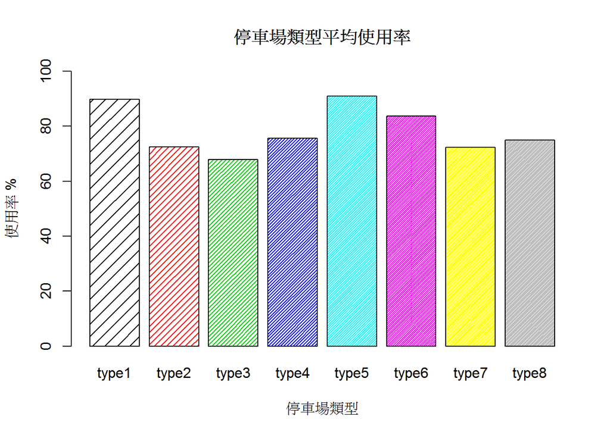

```r
barplot(sumTable$'AllTime_AVRTU(%)',
        main = "停車場類型平均使用率",
        ylab="使用率 %",
        xlab="停車場類型",
        col = c(1:8),
        ylim = c(0, 100),
        names.arg = c("type1", "type2", "type3", "type4",
                      "type5", "type6", "type7", "type8"),
        density=c(10,20,30,40,50,60,70,80))
```

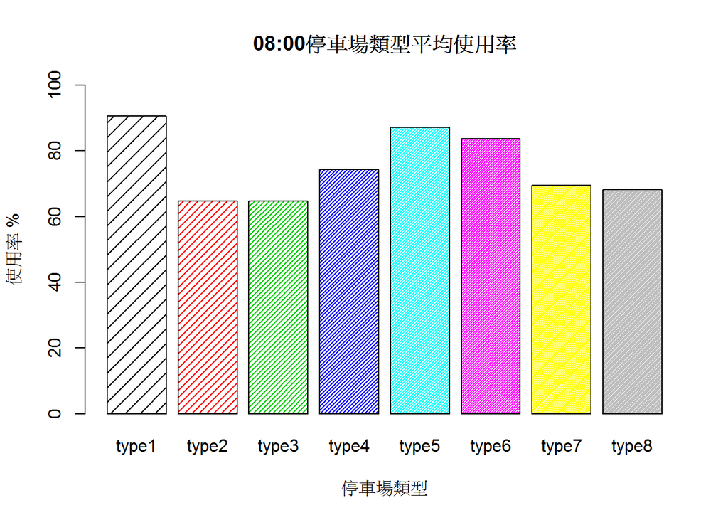

```r
barplot(sumTable$'0800_AVRTU(%)',
        main = "08:00停車場類型平均使用率",
        ylab="使用率 %",
        xlab="停車場類型",
        col = c(1:8),
        ylim = c(0, 100),
        names.arg = c("type1", "type2", "type3", "type4",
                      "type5", "type6", "type7", "type8"),
        density=c(10,20,30,40,50,60,70,80))
```

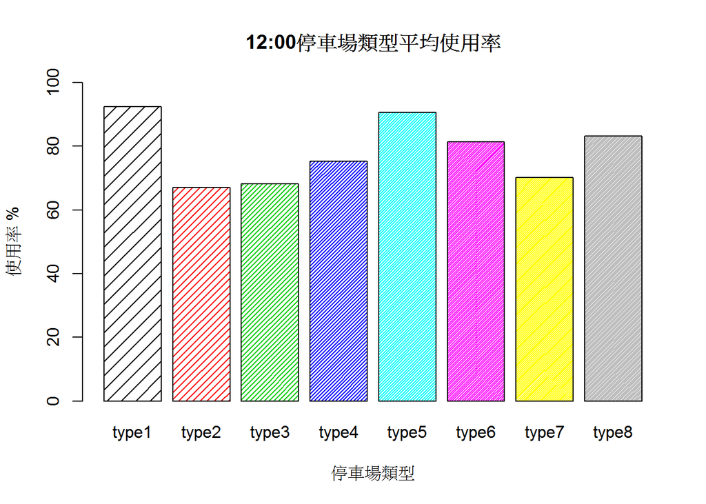

```r
barplot(sumTable$'1200_AVRTU(%)',
        main = "12:00停車場類型平均使用率",
        ylab="使用率 %",
        xlab="停車場類型",
        col = c(1:8),
        ylim = c(0, 100),
        names.arg = c("type1", "type2", "type3", "type4",
                      "type5", "type6", "type7", "type8"),
        density=c(10,20,30,40,50,60,70,80))
```

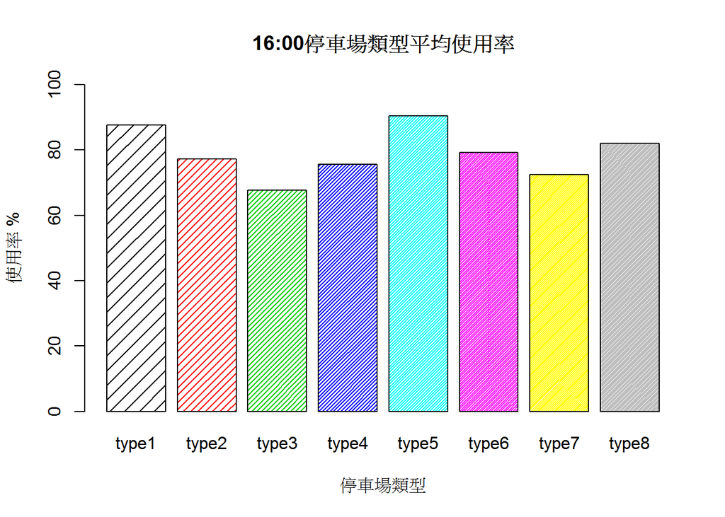

```r
barplot(sumTable$'1600_AVRTU(%)',
        main = "16:00停車場類型平均使用率",
        ylab="使用率 %",
        xlab="停車場類型",
        col = c(1:8),
        ylim = c(0, 100),
        names.arg = c("type1", "type2", "type3", "type4",
                      "type5", "type6", "type7", "type8"),
        density=c(10,20,30,40,50,60,70,80))
```

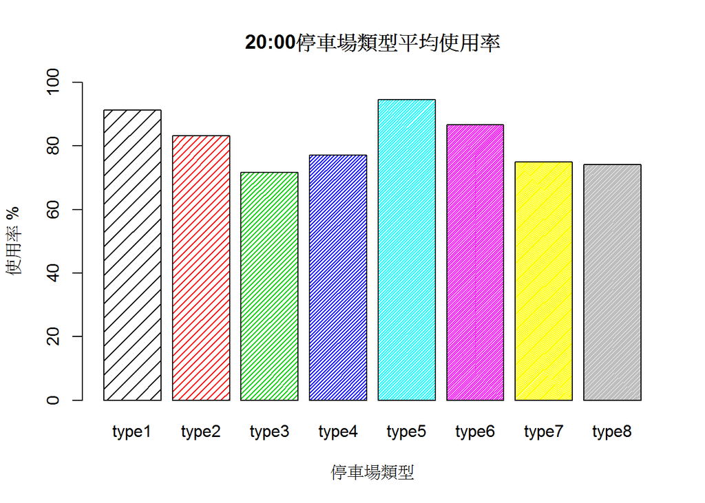

```r
barplot(sumTable$'2000_AVRTU(%)',
        main = "20:00停車場類型平均使用率",
        ylab="使用率 %",
        xlab="停車場類型",
        col = c(1:8),
        ylim = c(0, 100),
        names.arg = c("type1", "type2", "type3", "type4",
                      "type5", "type6", "type7", "type8"),
        density=c(10,20,30,40,50,60,70,80))
```

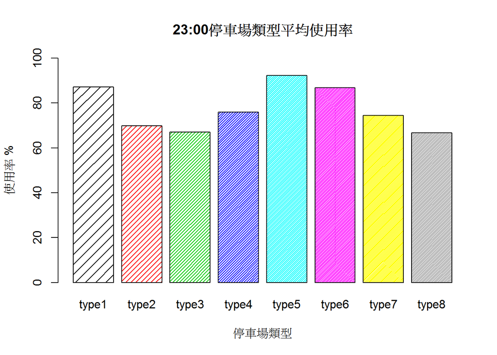

```r
barplot(sumTable$'2300_AVRTU(%)',
        main = "23:00停車場類型平均使用率",
        ylab="使用率 %",
        xlab="停車場類型",
        col = c(1:8),
        ylim = c(0, 100),
        names.arg = c("type1", "type2", "type3", "type4",
                      "type5", "type6", "type7", "type8"),
        density=c(10,20,30,40,50,60,70,80))
```

即時直接自開放平台下載剩餘車位資訊地圖

```r
url <- 'http://data.ntpc.gov.tw/api/v1/rest/datastore/382000000A-000292-002'
currpark <- fromJSON(url)
currpark <- as.data.frame(currpark[2]$result$records) # or currpark[2]records
currpark <- currpark[!duplicated(currpark[, 'ID']), ]
currpark$ID <- as.integer(currpark$ID)
currpark$AVAILABLECAR <- as.integer(currpark$AVAILABLECAR)
currpark <- currpark[which(currpark$AVAILABLECAR > 10),]
ptable <- merge(ptable, currpark, by = "ID", all.x = FALSE)

map1 <-
  leaflet() %>%
  addTiles() %>%  # 加上預設的地圖資料
  addMarkers(lat = ptable$WGS84X,
                   lng = ptable$WGS84Y,
                   popup = paste("名稱:", ptable$NAME, "<br>",
                                 "停車場類型:", ptable$SUMMARY, "<br>",
                                 "地址:", ptable$ADDRESS, "<br>",
                                 "目前剩餘空位數:", ptable$AVAILABLECAR))
map1  # 繪製地圖
```

[interactive chart not shown]